# Ustica_Report

Aceti Alessia, De Vivo Massimo, Rossi Diego

2024-01-08

Aceti Alessia matricola: 1079023 De Vivo Massimo matricola: 1081227 Rossi Diego matricola: 1073945

# Impact of Cattle Farming on Air Quality and Mitigation Prospects

# Sources:

Fasso_et_al_2023_ScientificData.pdf

# Introduction:

The issue of air pollution caused by agricultural activities, particularly cattle farming, has gained increasing attention within the scientific community. Numerous studies have highlighted the association between cattle farms and the rise in concentrations of atmospheric particulate matter (PM10) and other air pollutants. Understanding these impacts is crucial for developing effective environmental mitigation strategies.

# Key Variables:

Our study focuses on several key variables, with particular emphasis on:

- PM10: Atmospheric particulate matter with an aerodynamic diameter less than 10 μm.
- PM25: Atmospheric particulate matter with an aerodynamic diameter less than 2.5 μm.
- NOx e NO2: Nitrogen oxides associated with agricultural emissions.
- Cattle density: The number of cattle per unit area, reflecting the intensity of farming.

## Variabile risposta y

PM10: Particulate matter with an aerodynamic diameter of less than 10 μm

We designated PM10 as the response variable because, among the pollution variables, its altered trend was the closest to a normal distribution. Additionally, it had the fewest missing data points compared to the other pollution variables.

## **Explanatory Variable (x) to Address the Research Question

LI_bovine: Municipal density of bovines related to AQ stations

We selected cattle density as the explanatory variable because we are focused on investigating the impact of animal farming on air quality..

In addition, we utilized the following variables:

- WE_temp_2m: Temperature of air at 2 m above the surface of land, sea or inland water
- WE_wind_speed_10_mean: Mean intensity of the wind speed at a height of 10 m above the surface of the Earth

We included the variables WE_temp_2m and WE_wind_speed_10_mean to assess the effect of the `LI_bovine` variable on PM10 pollution from a conditional rather than a marginal perspective. The inclusion of these variables allows us to explore in greater depth and specificity the relationship between cattle density and air quality, while simultaneously considering temperature and wind speed.

# Research Question:

To what extent do cattle farming activities influence air quality, and which specific air pollutants are most strongly correlated with these agricultural practices?

# Theoretical Context:

Previous studies have shown that ammonia emissions from cattle farming can react with other atmospheric pollutants, influencing the formation of fine particulate matter. These mechanisms may vary depending on climatic conditions and agricultural practices employed. Some research suggests that reducing the size of cattle farms and implementing sustainable management techniques could significantly contribute to the reduction of air pollution associated with cattle farming.

# Methodology:

We will utilize air monitoring data and regression analysis to examine the relationships between cattle density, atmospheric emissions, and air quality.

# Objectives:

Evaluate the impact of cattle farming on PM10 concentrations. Identify significant correlations between cattle density, atmospheric conditions, and pollutant concentrations.

# Expected Conclusions:

We expect that the results will contribute to a clearer understanding of the impacts of cattle farming on air quality.

# Execution

As the first step, we imported the data from a specific dataset, from which we subsequently created the table `agri`.

```r
setwd("C:\\Users\\massimo\\Desktop\\UNIVERSITA'\\SECONDO ANNO\\STATISTICA\\PROGETTO")
load("Agrimonia_stations.RData")
ls()
```

```
## [1] "a"
```

```r
agri = a
dim(table(agri$NameStation))
```

```
## [1] 141
```

```r
head(agri)
```

```
##   IDStations           NameStation Province Latitude Longitude Altitude
## 1       1264 Sondrio Via Paribelli       SO 46.16785   9.87921      290
## 2       1264 Sondrio Via Paribelli       SO 46.16785   9.87921      290
## 3       1264 Sondrio Via Paribelli       SO 46.16785   9.87921      290
## 4       1264 Sondrio Via Paribelli       SO 46.16785   9.87921      290
## 5       1264 Sondrio Via Paribelli       SO 46.16785   9.87921      290
## 6       1264 Sondrio Via Paribelli       SO 46.16785   9.87921      290
##         Time AQ_pm10 AQ_pm25 AQ_co AQ_nh3 AQ_nox AQ_no2 AQ_so2 WE_temp_2m
## 1 2016-01-01      62      53   NaN    NaN  82.63  37.72    NaN     -2.212
## 2 2016-01-02      73      63   NaN    NaN 101.70  38.84    NaN     -3.063
## 3 2016-01-03      44      39   NaN    NaN  66.26  32.34    NaN     -2.768
## 4 2016-01-04      31      29   NaN    NaN  63.31  31.67    NaN     -4.352
## 5 2016-01-05      27      26   NaN    NaN  75.53  33.33    NaN     -6.184
## 6 2016-01-06      27      25   NaN    NaN  61.36  34.40    NaN     -6.427
##   WE_wind_speed_10m_mean WE_wind_speed_10m_max WE_mode_wind_direction_10m
```

[output cut: 48 more lines]

```r
dim(agri)
```

```
## [1] 309072     43
```

```r
names(agri)
```

```
##  [1] "IDStations"                  "NameStation"
##  [3] "Province"                    "Latitude"
##  [5] "Longitude"                   "Altitude"
##  [7] "Time"                        "AQ_pm10"
##  [9] "AQ_pm25"                     "AQ_co"
## [11] "AQ_nh3"                      "AQ_nox"
## [13] "AQ_no2"                      "AQ_so2"
## [15] "WE_temp_2m"                  "WE_wind_speed_10m_mean"
## [17] "WE_wind_speed_10m_max"       "WE_mode_wind_direction_10m"
## [19] "WE_tot_precipitation"        "WE_precipication_t"
## [21] "WE_surface_pressure"         "WE_solar_radiation"
## [23] "WE_rh_min"                   "WE_rh_mean"
## [25] "WE_rh_max"                   "WE_wind_speed_100m_mean"
## [27] "WE_wind_speed_100m_max"      "WE_mode_wind_direction_100m"
## [29] "WE_blh_layer_max"            "WE_blh_layer_min"
## [31] "EM_nh3_livestock_mm"         "EM_nh3_agr_soils"
## [33] "EM_nh3_agr_waste_burn"       "EM_nh3_sum"
## [35] "EM_nox_traffic"              "EM_nox_sum"
## [37] "EM_so2_sum"                  "LI_pigs"
## [39] "LI_bovine"                   "LA_hvi"
## [41] "LA_lvi"                      "LA_land_use"
## [43] "LA_soil_use"
```

```r
agri$NameStation = as.factor(agri$NameStation)
agri$Province = as.factor(agri$Province)
summary(agri$NameStation)
```

```
##                        Abbadia Cerreto Via Fanfulla
##                                                2192
##                                  Alessandria_T0643A
##                                                2192
##                                  Alessandria_T1830A
##                                                2192
##                             Arconate Via De Gasperi
##                                                2192
##                               Badia Polesine_T2072A
##                                                2192
##                               Bergamo Via Garibaldi
##                                                2192
##                                  Bergamo Via Meucci
##                                                2192
##                                  Bertonico Via Moro
##                                                2192
##                                    Besenzone_T1924A
##                                                2192
##                      Borgofranco Sul Po Loc Bonizzo
##                                                2192
##                                  Borgomanero_T2121A
##                                                2192
##                                   Borgosesia_T1532A
##                                                2192
##                            Bormio Via Monte Braulio
##                                                2192
##                                    Brescia San Polo
##                                                2192
##                                Brescia Via Broletto
##                                                2192
##                               Brescia Via Tartaglia
##                                                2192
##                                  Brescia Via Turati
##                                                2192
##                            Brescia Villaggio Sereno
##                                                2192
##                                      Busalla_T1026A
##                                                2192
##                                      Busalla_T1751A
##                                                2192
```

[output cut: 145 more lines]

```
##                                                2192
##                                        Parma_T0804A
##                                                2192
##                                        Parma_T1105A
##                                                2192
##                            Parona Via Della Miseria
##                                                2192
##                                  Pavia Pzza Minerva
##                                                2192
##                                  Pavia Via Folperti
##                                                2192
##                         Perledo Pzza Della Stazione
##                                                2192
##                                             (Other)
##                                               92064
```

We chose to select two distinct days, one during the summer and one during the winter, in order to compare atmospheric and pollution conditions between the two opposite seasons.

```r
agri_da = agri[agri$Time=="2017-07-11",]
agri_da2= agri[agri$Time=="2017-01-11",]
dim(agri_da)
```

```
## [1] 141  43
```

After reviewing the table, we proceeded to eliminate all stations that had missing values for the variable related to cattle density. This step allows us to work with a more complete and consistent dataset for our analysis.

```r
#estate
agri_da_y = agri_da[!is.na(agri_da$LI_bovine),]
dim(agri_da_y)
```

```
## [1] 138  43
```

```r
#inverno
agri_da_x = agri_da2[!is.na(agri_da$LI_bovine),]
dim(agri_da_x)
```

```
## [1] 138  43
```

We calculated and visualized the variability in the number of cattle at the selected stations during summer and winter.

This enabled us to examine the seasonal differences in cattle numbers and understand how this variability might influence air pollution during different seasons.

We observed low variability in the number of cattle throughout the year; therefore, we chose to focus on a single study day and conduct the analysis considering all stations instead of just one.

```r
cat("variabilità bovini estate", "\n")
```

```
## variabilità bovini estate
```

```r
summary(agri_da_y$LI_bovine)
```

```
##    Min. 1st Qu.  Median    Mean 3rd Qu.    Max.
##   0.000   3.102  11.580  36.953  45.200 389.100
```

```r
cat("variabilità bovini inverno", "\n")
```

```
## variabilità bovini inverno
```

```r
summary(agri_da_x$LI_bovine)
```

```
##    Min. 1st Qu.  Median    Mean 3rd Qu.    Max.
##    0.00    3.64   12.93   37.09   46.60  395.60
```

Visualizziamo la variabilità delle variabili inquinanti rispettivamente in estate ed in inverno.

```r
# ESTATE
cat("variabilità pm_10 estate", "\n")
```

```
## variabilità pm_10 estate
```

```r
summary(agri_da_y$AQ_pm10,)
```

```
##    Min. 1st Qu.  Median    Mean 3rd Qu.    Max.    NA's
##    4.00   14.00   18.00   18.39   22.00   50.00      41
```

```r
cat("variabilità pm_25 estate", "\n")
```

```
## variabilità pm_25 estate
```

```r
summary(agri_da_y$AQ_pm25)
```

```
##    Min. 1st Qu.  Median    Mean 3rd Qu.    Max.    NA's
##    3.00    9.00   11.00   11.43   14.75   17.00      92
```

```r
cat("variabilità nox estate", "\n")
```

```
## variabilità nox estate
```

```r
summary(agri_da_y$AQ_nox)
```

```
##    Min. 1st Qu.  Median    Mean 3rd Qu.    Max.    NA's
##   3.291  13.980  21.240  26.309  33.110 113.600      57
```

```r
# INVERNO
cat("variabilità pm10 estate", "\n")
```

```
## variabilità pm10 estate
```

```r
summary(agri_da_x$AQ_pm10,)
```

```
##    Min. 1st Qu.  Median    Mean 3rd Qu.    Max.    NA's
##    5.00   39.00   44.00   43.99   48.25   74.00      38
```

```r
cat("variabilità pm25 inverno", "\n")
```

```
## variabilità pm25 inverno
```

```r
summary(agri_da_x$AQ_pm25)
```

```
##    Min. 1st Qu.  Median    Mean 3rd Qu.    Max.    NA's
##   20.00   29.00   32.50   33.68   38.00   60.00      90
```

```r
cat("variabilità nox inverno", "\n")
```

```
## variabilità nox inverno
```

```r
summary(agri_da_x$AQ_nox)
```

```
##    Min. 1st Qu.  Median    Mean 3rd Qu.    Max.    NA's
##   6.287  44.900  62.275  69.513  85.510 265.700      58
```

The concentration of particulate matter (PM10 and PM2.5) shows an increase in winter compared to summer.

The variability of NOx emissions is higher in winter than in summer, indicating increased human activity during this season.

The trends may be influenced by various factors such as domestic heating, traffic, and seasonal weather conditions.

```r
mean_pm10_estate <- mean(agri_da_y$AQ_pm10, na.rm = TRUE)
mean_pm10_inverno <- mean(agri_da_x$AQ_pm10, na.rm = TRUE)

mean_pm25_estate <- mean(agri_da_y$AQ_pm25, na.rm = TRUE)
mean_pm25_inverno <- mean(agri_da_x$AQ_pm25, na.rm = TRUE)

mean_nox_estate <- mean(agri_da_y$AQ_nox, na.rm = TRUE)
mean_nox_inverno <- mean(agri_da_x$AQ_nox, na.rm = TRUE)

cat("Media PM10 in estate:", mean_pm10_estate, "\n")
```

```
## Media PM10 in estate: 18.38992
```

```r
cat("Media PM10 in inverno:", mean_pm10_inverno, "\n")
```

```
## Media PM10 in inverno: 43.9887
```

```r
cat("Media PM2.5 in estate:", mean_pm25_estate, "\n")
```

```
## Media PM2.5 in estate: 11.4342
```

```r
cat("Media PM2.5 in inverno:", mean_pm25_inverno, "\n")
```

```
## Media PM2.5 in inverno: 33.68062
```

```r
cat("Media NOx in estate:", mean_nox_estate, "\n")
```

```
## Media NOx in estate: 26.3088
```

```r
cat("Media NOx in inverno:", mean_nox_inverno, "\n")
```

```
## Media NOx in inverno: 69.51309
```

I calcoli delle medie confermano ulteriormente le differenze di inquinamento tra la stagione estiva e quella invernale.

# Analisi variabile risposta

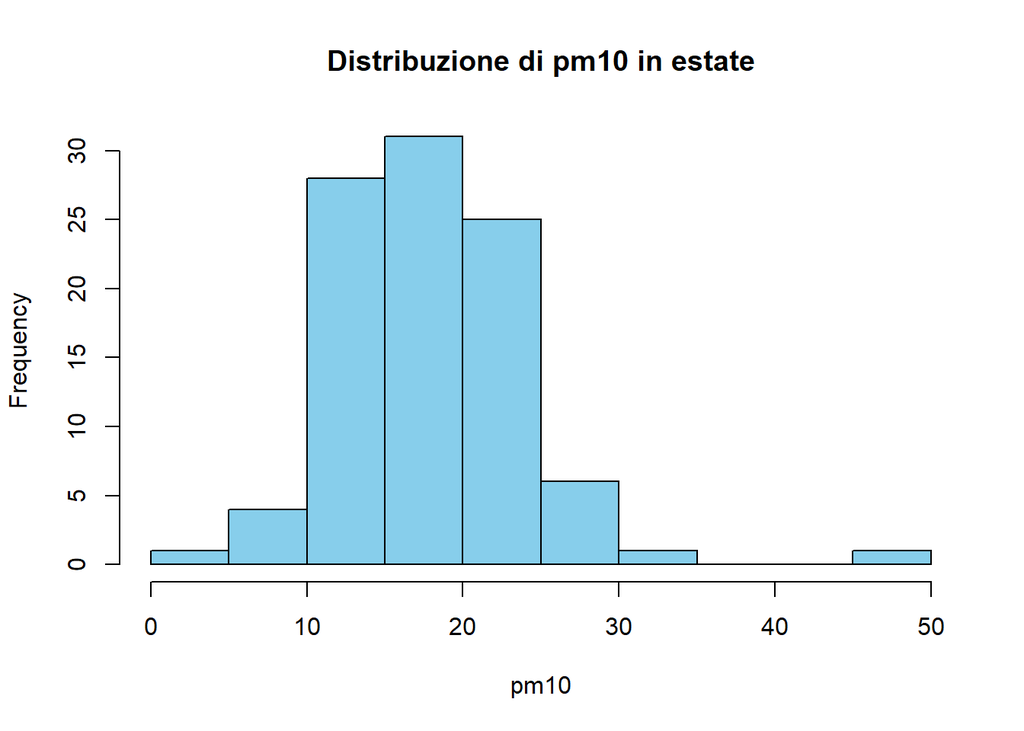

```r
#ESTATE pm10
# histogram
hist(agri_da_y$AQ_pm10, main = "Distribuzione di pm10 in estate", xlab = "pm10", col = "skyblue", border = "black")
```

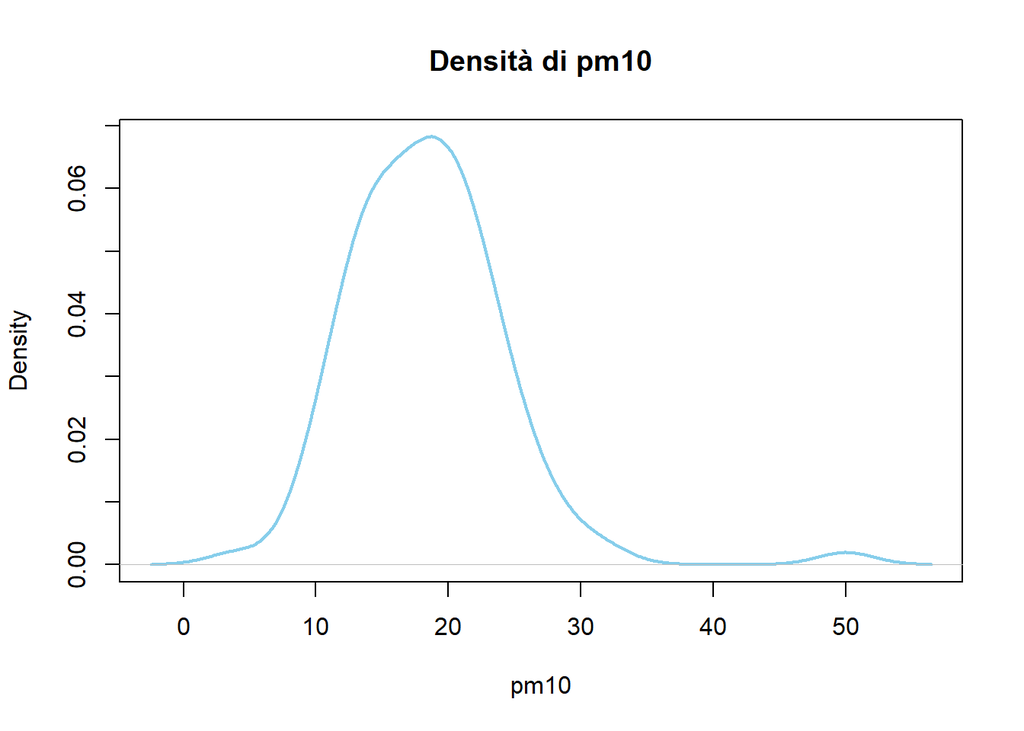

```r
#plot density
plot(density(agri_da_y$AQ_pm10, na.rm = TRUE), main = "Densità di pm10", xlab = "pm10", col = "skyblue", lwd = 2)
```

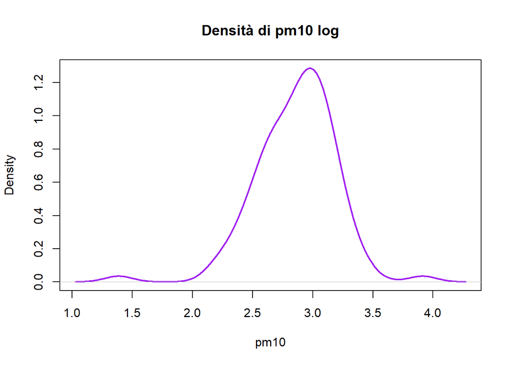

```r
plot(density(log(agri_da_y$AQ_pm10),na.rm = TRUE), main = "Densità di pm10 log", xlab = "pm10", col = "purple", lwd = 2)
```

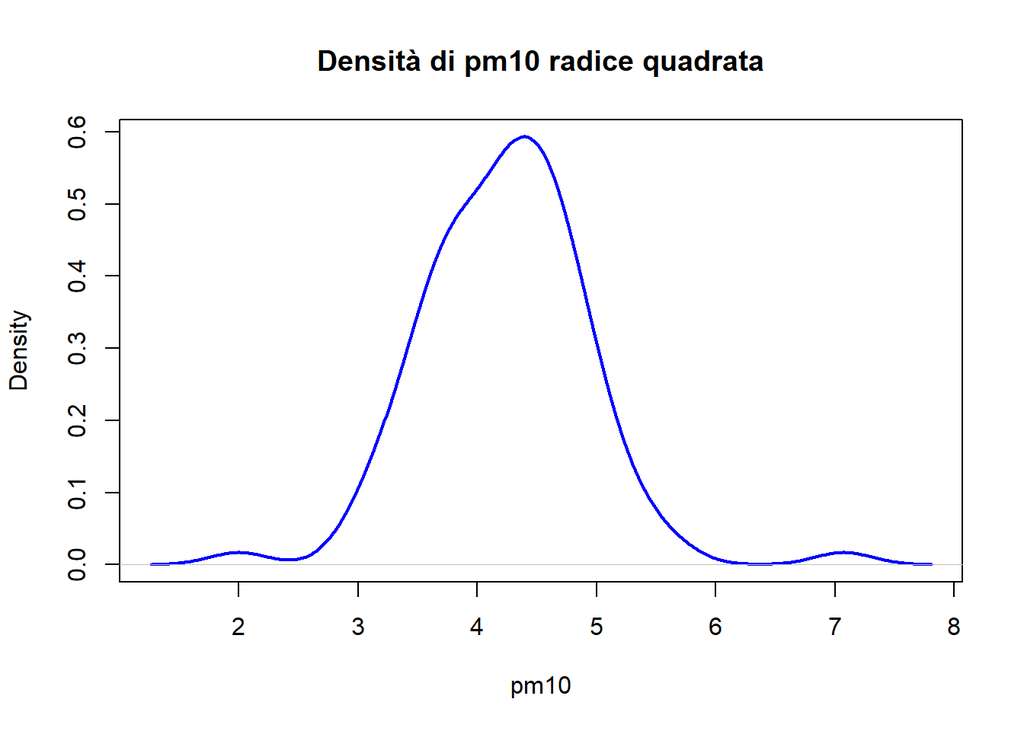

```r
plot(density(sqrt(agri_da_y$AQ_pm10), na.rm = TRUE), main = "Densità di pm10 radice quadrata", xlab = "pm10", col = "blue", lwd = 2)
```

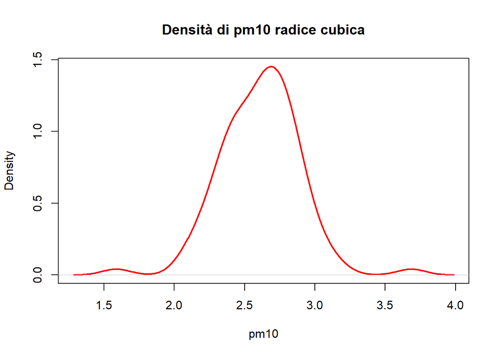

```r
plot(density((agri_da_y$AQ_pm10)^(1/3), na.rm = TRUE), main = "Densità di pm10 radice cubica", xlab = "pm10", col = "red", lwd = 2)
```

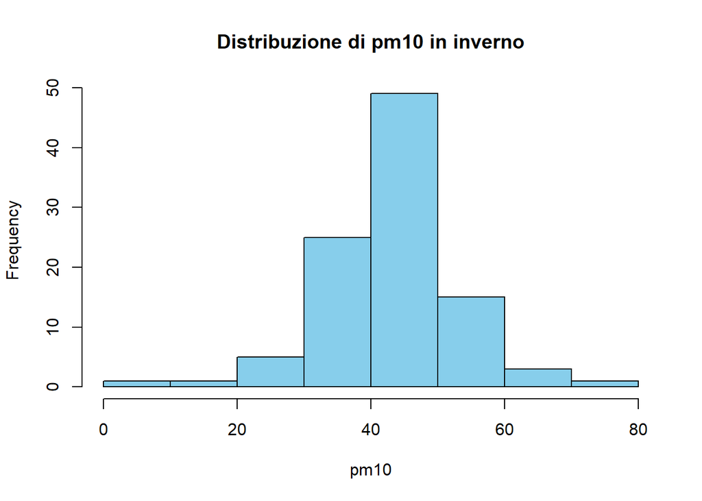

```r
# INVERNO pm10

# histogram
hist(agri_da_x$AQ_pm10, main = "Distribuzione di pm10 in inverno", xlab = "pm10", col = "skyblue", border = "black")
```

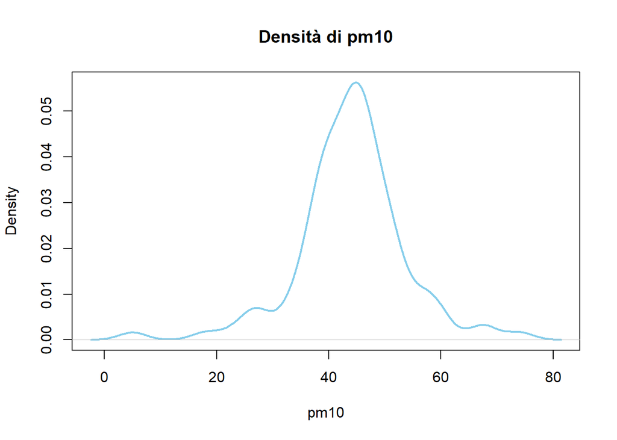

```r
#plot density
plot(density(agri_da_x$AQ_pm10, na.rm = TRUE), main = "Densità di pm10", xlab = "pm10", col = "skyblue", lwd = 2)
```

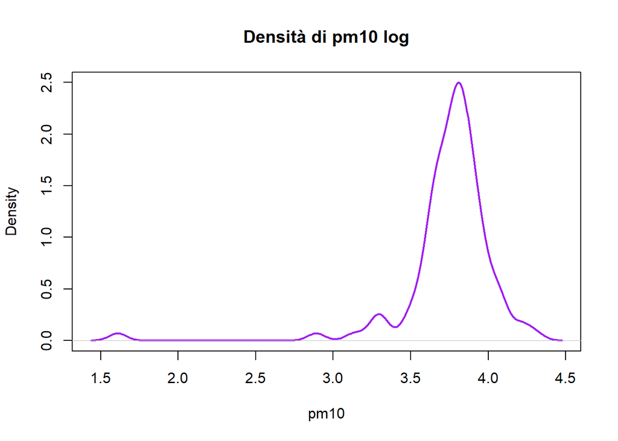

```r
plot(density(log(agri_da_x$AQ_pm10),na.rm = TRUE), main = "Densità di pm10 log", xlab = "pm10", col = "purple", lwd = 2)
```

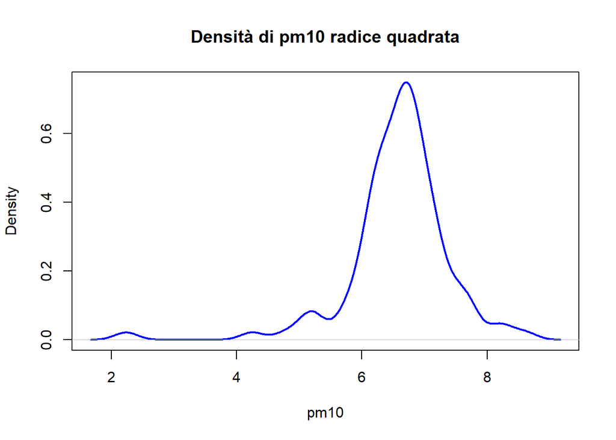

```r
plot(density(sqrt(agri_da_x$AQ_pm10), na.rm = TRUE), main = "Densità di pm10 radice quadrata", xlab = "pm10", col = "blue", lwd = 2)
```

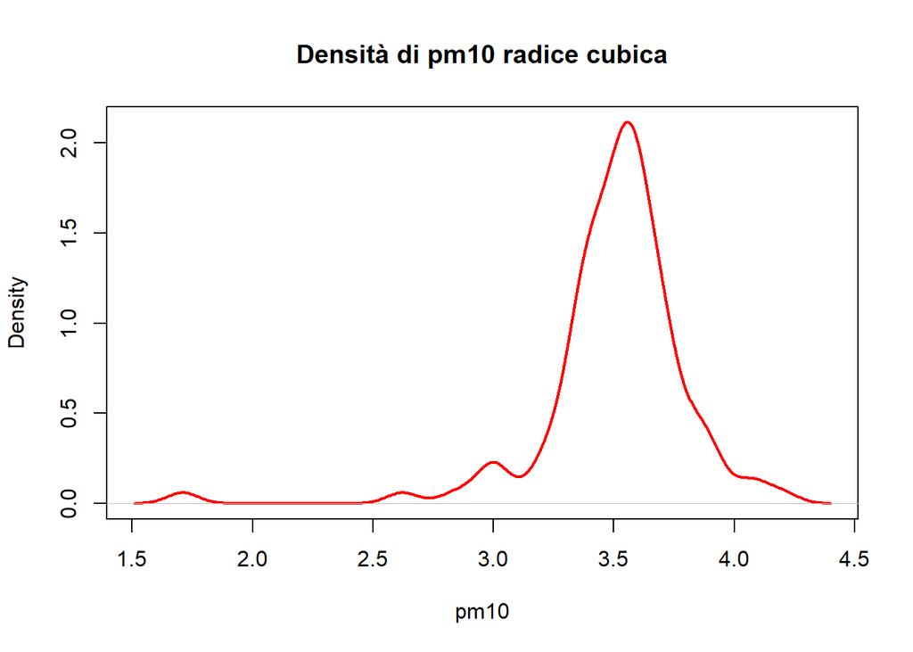

```r
plot(density((agri_da_x$AQ_pm10)^(1/3), na.rm = TRUE), main = "Densità di pm10 radice cubica", xlab = "pm10", col = "red", lwd = 2)
```

Abbiamo esplorato diverse tecniche per normalizzare la distribuzione di PM10, utilizzando grafici distinti per la stagione estiva e invernale.

Per il giorno estivo, abbiamo applicato la radice cubica, ottenendo una distribuzione che approssima una forma più normale. Questo metodo è stato scelto per mitigare la possibile asimmetria nella distribuzione dei dati.

Per il giorno invernale, abbiamo mantenuto il grafico senza approssimazioni. Questa scelta è stata motivata dalla forma della distribuzione invernale, che sembrava già più simmetrica rispetto alla distribuzione estiva.

L’obiettivo di queste trasformazioni è rendere la distribuzione dei dati più aderente all’assunzione di normalità, facilitando così l’applicazione di modelli di regressione.

# Correlazione

```r
#ESTATE
library(corrplot)
cor_matrix_estate <- cor(agri_da_y[, c("AQ_pm10", "AQ_pm25", "LI_bovine", "AQ_nox")],use = "complete.obs")
cat("Correlazione variabili in estate")
```

```
## Correlazione variabili in estate
```

```r
cat("\n")
```

```r
print(cor_matrix_estate)
```

```
##             AQ_pm10    AQ_pm25 LI_bovine     AQ_nox
## AQ_pm10   1.0000000  0.4501331 0.1744309  0.1022128
## AQ_pm25   0.4501331  1.0000000 0.1213552 -0.1752040
## LI_bovine 0.1744309  0.1213552 1.0000000  0.1114228
## AQ_nox    0.1022128 -0.1752040 0.1114228  1.0000000
```

```r
cat("\n")
```

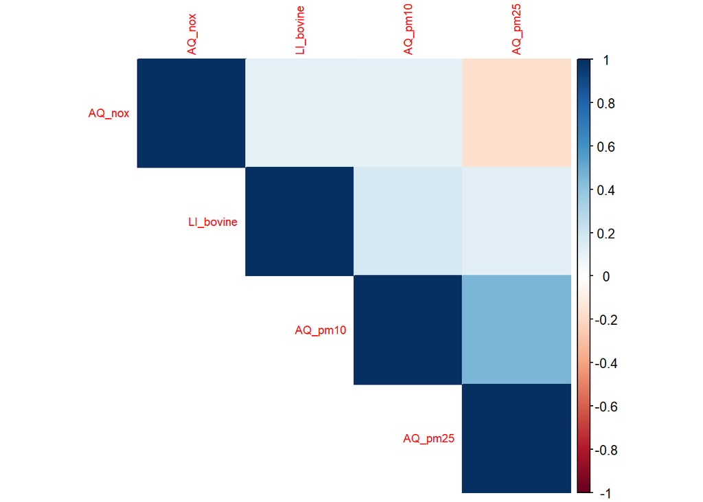

```r
corrplot(cor_matrix_estate, method = "color", type = "upper", order = "hclust", tl.cex = 0.7)
```

```r
#INVERNO
cor_matrix_inverno <- cor(agri_da_x[, c("AQ_pm10", "AQ_pm25", "LI_bovine", "AQ_nox")],use = "complete.obs")
cat("Correlazione variabili in inverno")
```

```
## Correlazione variabili in inverno
```

```r
cat("\n")
```

```r
print(cor_matrix_inverno)
```

```
##              AQ_pm10    AQ_pm25  LI_bovine     AQ_nox
## AQ_pm10    1.0000000  0.7532988 -0.1187138  0.5338226
## AQ_pm25    0.7532988  1.0000000 -0.2952709  0.3379343
## LI_bovine -0.1187138 -0.2952709  1.0000000 -0.0948925
## AQ_nox     0.5338226  0.3379343 -0.0948925  1.0000000
```

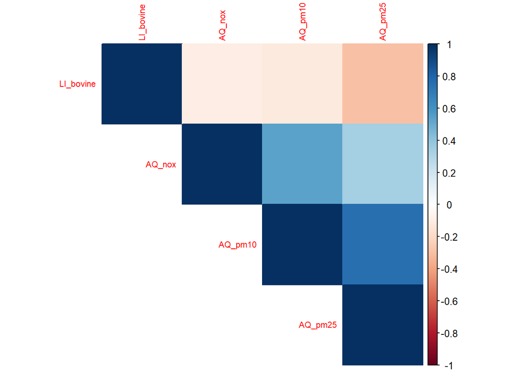

```r
corrplot(cor_matrix_inverno, method = "color", type = "upper", order = "hclust", tl.cex = 0.7)
```

We examined the correlation between cattle density and various atmospheric pollutants in both summer and winter.

In summer, we observed a positive, albeit weak, correlation between cattle density and pollutants. This suggests that during the summer season, emissions from cattle farming may have a minimal influence on air quality. However, the weak correlation indicates that other factors could play a more significant role in atmospheric pollution during this season.

In winter, the correlation is weakly negative, suggesting that cattle density does not significantly influence atmospheric pollution during this season. This may be attributed to the presence of other pollutants that dominate the overall impact on air quality, rendering the influence of cattle relatively negligible by comparison.

It is essential to highlight that correlation does not inherently imply a causal relationship; other factors may play a more significant role in contributing to atmospheric pollution.

# Linear model

```r
# estate
model_pm10 <- lm((AQ_pm10)^(1/3) ~ LI_bovine, data = agri_da_y)
model_pm10_2 <- lm((AQ_pm10)^(1/3) ~ LI_bovine + WE_temp_2m +WE_wind_speed_10m_mean,  data = agri_da_y)
cat("Modello lineare a una variabile (Summer)", "\n")
```

```
## Modello lineare a una variabile (Summer)
```

```r
summary(model_pm10)
```

```
##
## Call:
## lm(formula = (AQ_pm10)^(1/3) ~ LI_bovine, data = agri_da_y)
##
## Residuals:
##      Min       1Q   Median       3Q      Max
## -1.00825 -0.15448 -0.00386  0.15758  0.99956
##
## Coefficients:
##              Estimate Std. Error t value Pr(>|t|)
## (Intercept) 2.5526151  0.0345375  73.908  < 2e-16 ***
## LI_bovine   0.0017673  0.0006407   2.758  0.00697 **
## ---
## Signif. codes:  0 '***' 0.001 '**' 0.01 '*' 0.05 '.' 0.1 ' ' 1
##
## Residual standard error: 0.2717 on 95 degrees of freedom
##   (41 osservazioni eliminate a causa di valori mancanti)
## Multiple R-squared:  0.07415,    Adjusted R-squared:  0.06441
## F-statistic: 7.609 on 1 and 95 DF,  p-value: 0.006968
```

```r
cat("Modello lineare a più variabili (estate)", "\n")
```

```
## Modello lineare a più variabili (estate)
```

```r
summary(model_pm10_2)
```

```
##
## Call:
## lm(formula = (AQ_pm10)^(1/3) ~ LI_bovine + WE_temp_2m + WE_wind_speed_10m_mean,
##     data = agri_da_y)
##
## Residuals:
##      Min       1Q   Median       3Q      Max
## -0.58109 -0.13563 -0.01268  0.12866  0.95168
##
## Coefficients:
##                         Estimate Std. Error t value Pr(>|t|)
## (Intercept)            1.6394291  0.1763540   9.296 6.31e-15 ***
## LI_bovine              0.0009026  0.0005507   1.639 0.104578
## WE_temp_2m             0.0371794  0.0102882   3.614 0.000489 ***
## WE_wind_speed_10m_mean 0.0463938  0.0547658   0.847 0.399096
## ---
## Signif. codes:  0 '***' 0.001 '**' 0.01 '*' 0.05 '.' 0.1 ' ' 1
##
## Residual standard error: 0.2254 on 93 degrees of freedom
##   (41 osservazioni eliminate a causa di valori mancanti)
## Multiple R-squared:  0.3763, Adjusted R-squared:  0.3561
## F-statistic:  18.7 on 3 and 93 DF,  p-value: 1.421e-09
```

### In the univariate linear model, we observe that:

#### Interpretation of the Coefficients:

The intercept is approximately 2.55, indicating that when cattle density is zero, the expected cubic concentration of PM10 is around 2.55.

The coefficient for `LI_bovine` is 0.00177, with a standard error of 0.00064. The associated p-value for `LI_bovine` is 0.00697, indicating that the coefficient is statistically significant. Practically, an increase in cattle density is associated with an estimated increase of 0.00177 in the cubic mean of PM10 during the summer.

#### Goodness of Fit of the Model:

The coefficient of determination (R-squared) is 0.07415, indicating that 7.4% of the variation in the cubic mean of AQ_pm10 can be explained by the variable `LI_bovine` during the summer.

#### Overall Model Assessment:

The **p-value** associated with the **F-statistic** is 0.00697, indicating that the model as a whole is statistically significant.

### In the multiple linear regression model:

#### Interpretation of the coefficients:

The **intercept** is approximately 1.64. This means that when all independent variables are zero, the expected cubic concentration of `AQ_pm10` is about 1.64 during the summer.

The coefficient for `LI_bovine` is 0.0009026, with a `p-value` of 0.104578, indicating that cattle density is not significant during the summer.

The coefficient for `WE_temp_2m` is 0.0371794, with a very low p-value (0.000489), indicating that `WE_temp_2m` is significant and positively associated with the cubic mean of `pm10` during the summer.

The coefficient for `WE_wind_speed_10m_mean` is 0.0463938, but the p-value is 0.399096, indicating that this coefficient is not significant during the summer.

#### Goodness of fit of the model:

The coefficient of determination (R-squared) is 0.3763, indicating that 37.63% of the variation in the cubic mean of `AQ_pm10` can be explained by the predictive variables in the model during the summer.

#### Global model assessment:

The p-value associated with the F-statistic is very low (1.421e-09), indicating that the model as a whole is highly significant during the summer.

#### General Comments:

The linear model with a single variable during the summer shows a significant relationship between cattle density and `PM10` concentration.

However, the multiple variable model suggests that other factors, such as temperature (WE_temp_2m), are more influential.

Both models, however, have relatively low R-squared values, suggesting that other unaccounted factors may significantly contribute to the variation in PM10 concentration during the summer.

In conclusion, we can state that the second model with multiple variables appears to explain a greater percentage of the variation in `PM10` cubic mean compared to the first model with a single variable.

It is important to note that the variable `LI_bovine` in the multiple variable model was not significant at a 5% significance level. This suggests that, when considering meteorological variables as well, the density of `bovine` may not have a significant impact on the concentration of `pm10` in the air.

Furthermore, the variable **`WE_wind_speed_10m_mean`** was not found to be significant, indicating that wind speed at 10 meters may not be a determining factor in explaining the variability of **`AQ_pm10`** in our context.

```r
#inverno

model_pm10_inv <- lm(AQ_pm10 ~ LI_bovine, data = agri_da_x)
model_pm10_inv_2 <- lm(AQ_pm10 ~ LI_bovine + WE_temp_2m + WE_wind_speed_10m_mean, data = agri_da_x)
cat("Modello lineare a una variabile (inverno)", "\n")
```

```
## Modello lineare a una variabile (inverno)
```

```r
summary(model_pm10_inv)
```

```
##
## Call:
## lm(formula = AQ_pm10 ~ LI_bovine, data = agri_da_x)
##
## Residuals:
##     Min      1Q  Median      3Q     Max
## -39.299  -4.481   0.071   4.719  29.740
##
## Coefficients:
##             Estimate Std. Error t value Pr(>|t|)
## (Intercept) 44.33410    1.19764  37.018   <2e-16 ***
## LI_bovine   -0.01104    0.02224  -0.497    0.621
## ---
## Signif. codes:  0 '***' 0.001 '**' 0.01 '*' 0.05 '.' 0.1 ' ' 1
##
## Residual standard error: 9.75 on 98 degrees of freedom
##   (38 osservazioni eliminate a causa di valori mancanti)
## Multiple R-squared:  0.00251,    Adjusted R-squared:  -0.007668
## F-statistic: 0.2466 on 1 and 98 DF,  p-value: 0.6206
```

```r
cat("Modello lineare a più variabili (inverno)", "\n")
```

```
## Modello lineare a più variabili (inverno)
```

```r
summary(model_pm10_inv_2)
```

```
##
## Call:
## lm(formula = AQ_pm10 ~ LI_bovine + WE_temp_2m + WE_wind_speed_10m_mean,
##     data = agri_da_x)
##
## Residuals:
##     Min      1Q  Median      3Q     Max
## -42.269  -4.428   0.894   5.092  27.558
##
## Coefficients:
##                         Estimate Std. Error t value Pr(>|t|)
## (Intercept)            48.312222   5.527225   8.741 7.52e-14 ***
## LI_bovine              -0.005248   0.022892  -0.229    0.819
## WE_temp_2m             -0.273516   0.712669  -0.384    0.702
## WE_wind_speed_10m_mean -3.413528   3.023159  -1.129    0.262
## ---
## Signif. codes:  0 '***' 0.001 '**' 0.01 '*' 0.05 '.' 0.1 ' ' 1
##
## Residual standard error: 9.71 on 96 degrees of freedom
##   (38 osservazioni eliminate a causa di valori mancanti)
## Multiple R-squared:  0.03079,    Adjusted R-squared:  0.000507
## F-statistic: 1.017 on 3 and 96 DF,  p-value: 0.3888
```

### In the univariate linear model, we observe that:

#### Interpretation of the coefficients:

The intercept is approximately 44.33. This means that when the density of cattle is zero, the expected concentration of `pm10` is 44.33.

The coefficient for `LI_bovine` is -0.01104 with a standard error of 0.02224. However, the p-value associated with `LI_bovine` is 0.621, indicating that the coefficient is not significant. In practice, the density of cattle does not appear to have a significant impact on the concentration of `pm10` during winter.

#### Goodness of fit of the model:

The coefficient of determination (R-squared) is very low, indicating that only 0.25% of the variation in the concentration of `AQ_pm10` can be explained by the variable `LI_bovine` in this model.

#### Overall model assessment:

The p-value associated with the F-statistic is 0.6206, indicating that the model as a whole is not significant.

### In the multiple linear regression model, we observe that:

#### Interpretation of the coefficients:

The intercept is approximately `48.31`. This means that when all independent variables are zero, the expected concentration of `AQ_pm10` is `48.31`.

The coefficient for `LI_bovine` is `-0.005248`, with a p-value of `0.819`, indicating that the density of cattle is not significant.

The coefficient for `WE_temp_2m` is `-0.2735`, but the p-value is `0.702`, indicating that this variable is also not significant.

The coefficient for `WE_wind_speed_10m_mean` is `-3.4135`, with a p-value of `0.262`, indicating that this variable is also not significant.

#### Goodness of fit of the model:

The coefficient of determination (R-squared) is still low, indicating that only `3.08%` of the variation in `AQ_pm10` can be explained by the variables included in this model.

#### Global valuation of the model:

The p-value associated with the `F-statistic` is `0.3888`, indicating that the model as a whole is not significant.

### General comments:

Both models exhibit very low R-squared values and high p-values, indicating that the variables considered, including the density of cattle, do not adequately explain the variation in the concentration of `pm10` during winter. It may be beneficial to consider additional variables or explore more complex models to enhance the prediction of air pollution levels.

# Residual diagnostics plots

## Single-variable estimation

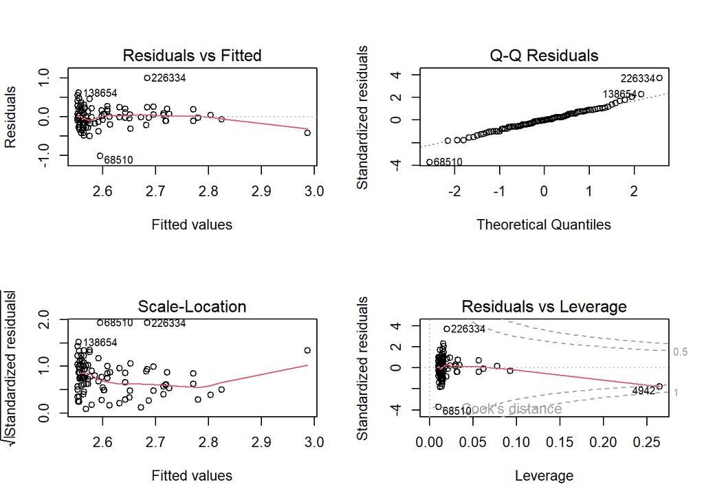

```r
par(mfrow = c(2, 2))
plot(model_pm10)
```

### Residuals vs Fitted:

The plot displays the residual errors against their estimated values. It features a red trend line for the residuals that is nearly horizontal, with few outlier points above and below it. This suggests that the linear model is adequate for describing the relationship in the data and does not highlight significant issues of non-linearity. In a more detailed analysis, we observe that the residuals are randomly distributed around the x-axis without showing particular trends, confirming that the model is appropriate and does not exhibit systematic deviations.

### Q-Q Residuals:

The plot shows the residuals against the quantiles of a normal distribution. If the residuals are normally distributed, the points on the plot should follow a straight line.

In this case, the points on the plot follow a straight line quite closely, indicating that the residuals are normally distributed. The linearity of the residuals' distribution contributes to the reliability of the model in making predictions and interpreting the data.

### Scale-Location:

In the plot, the residuals appear to be randomly distributed around the x-axis. However, the trend line of the residuals is slightly inclined upward for the higher values. This indicates that the variance of the residuals is greater for these values. Therefore, the assumption of homoscedasticity is not fully satisfied.

### Residuals vs Leverage:

The plot provides a visualization of the residuals in relation to leverage, a measure of the distance of each point from the observed data. Leverage is a metric that indicates how much a single point can influence the model. Specifically, if a point has high leverage, it means that it has a significant impact on the model's estimates and may be considered an outlier.

In this case, there are very few points with high leverage, indicating the presence of some possible outliers in the data. Additionally, the red trend line of the residuals shows a slight downward tendency.

### Conclusions:

In general, the plots displayed in the image indicate that the linear regression model is suitable for the data.

However, it is important to note that the variance of the residuals is not homogeneous, particularly at the extreme values, and that there are some outliers in the data. These factors indicate that the model could be improved.

## Summer multi-variables

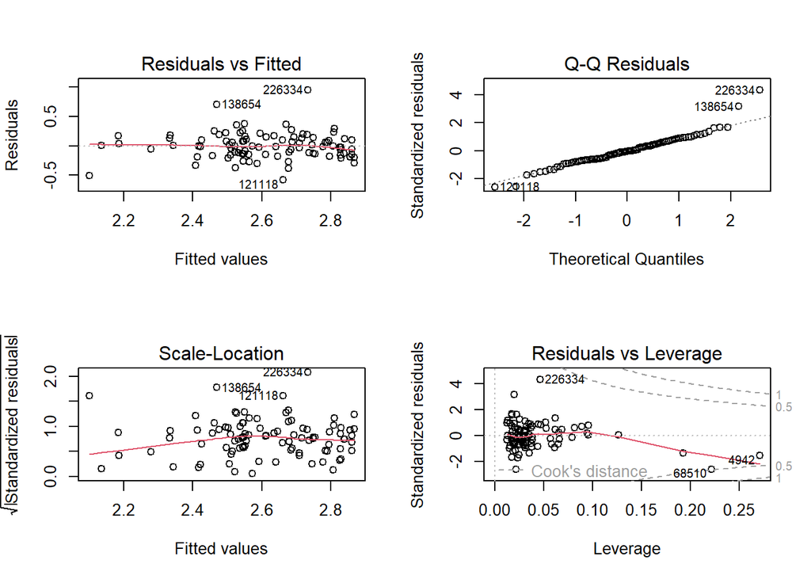

```r
par(mfrow = c(2,2))
plot(model_pm10_2)
```

### Residuals vs Fitted:

In the first plot, it can be observed that the red line overlaps with the zero line and that the residuals are distributed fairly randomly around the x-axis without showing particular trends. This suggests that the linear regression model is well-fitted to the data and does not exhibit significant issues of non-linearity.

### Q-Q Residuals:

In this context, the points on the plot approximately follow a straight line, indicating a fairly normal distribution of the residuals.

### Residuals vs Leverage:

In this case, there are some points with high leverage, indicating the presence of possible outliers in the data. Additionally, the red trend line of the residuals shows a downward tendency.

### Conclusions:

In general, the plots displayed in the image suggest that the linear regression model is suitable for the data.

## Winter single-variable

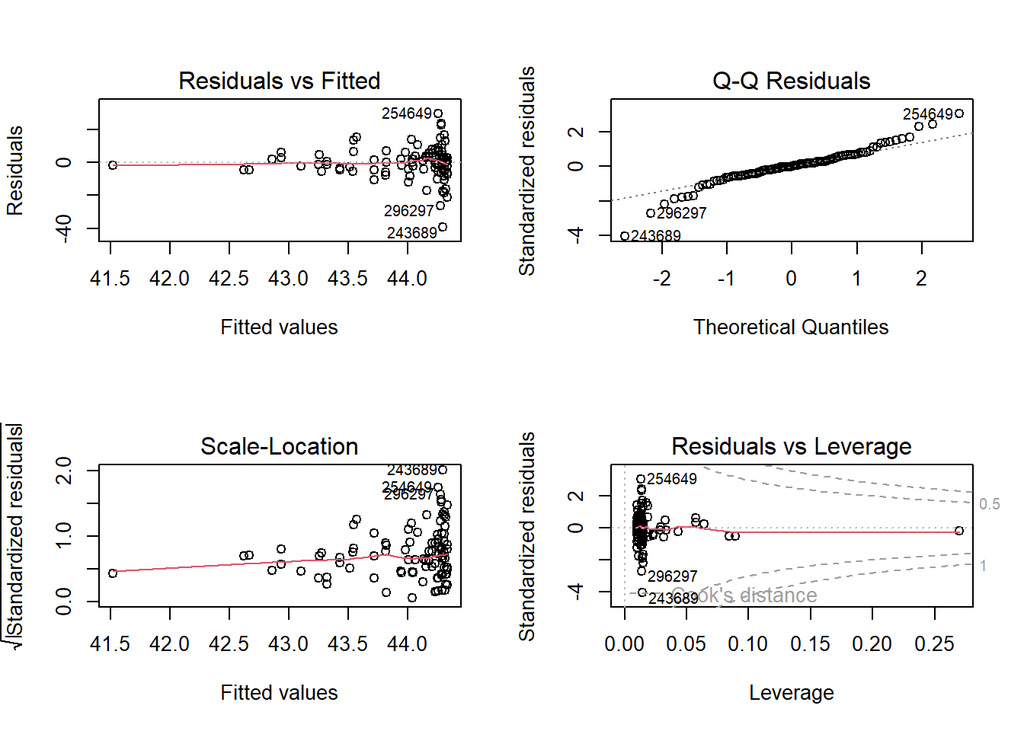

```r
par(mfrow = c(2, 2))
plot(model_pm10_inv)
```

### Residuals vs Fitted:

In this case, the red line closely follows the zero line, and the various points appear to be randomly distributed around the x-axis without exhibiting any specific trends. This suggests that the linear regression model is well-suited to the data, and no significant issues of non-linearity are apparent.

### Q-Q Residuals:

In this case, the points on the graph do not perfectly follow a straight line at the initial and final values; however, the residuals' distribution still resembles a normal distribution to a reasonable extent.

### Residuals vs Leverage:

In this case, there are very few points with high leverage, indicating the presence of some potential outliers in the data. Additionally, the red residual trend line is flat, suggesting that the linearity assumption should be further examined.

### Conclusions:

In general, the graphs suggest that the linear regression model fits the data well in terms of the random distribution of residuals around the x-axis and the normality of the residuals relative to the normal distribution.

However, they also highlight that the variance of the residuals is not entirely homogeneous and that there are some outliers in the data. These factors indicate that the model could be improved.

## Winter multi-variable

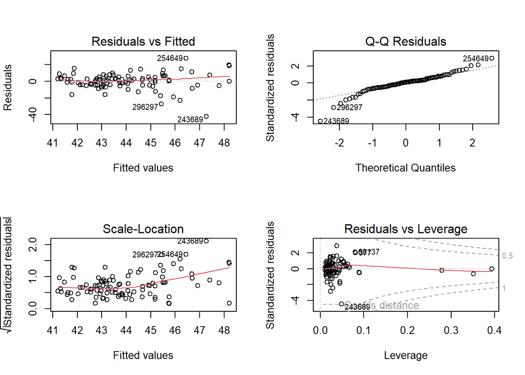

```r
par(mfrow = c(2, 2))
plot(model_pm10_inv_2)
```

### Residuals vs Fitted:

In this case, the red line approximately follows the zero line, and the residuals are randomly distributed around the x-axis without exhibiting any specific trends. This suggests that the linear regression model is suitable for the data, and no significant issues of non-linearity are evident.

### Q-Q Residuals:

In this case, the points on the graph do not perfectly align with a straight line at the initial and final values; however, the distribution of the residuals still resembles a normal distribution to a considerable extent.

### Residuals vs Leverage:

In this case, there are very few points with high leverage, indicating the presence of some potential outliers in the data. Additionally, the red residual trend line is flat, suggesting that the linearity assumption should be further examined.

### Conclusions:

In general, the graphs suggest that the linear regression model fits the data well in terms of the random distribution of residuals around the x-axis and the normality of the residuals relative to the normal distribution.

However, they also highlight that the variance of the residuals is not homogeneous, particularly at the final values, and that there are some outliers in the data. These factors indicate that the model could be improved.

# Final conslusion

The expected results were not observed in the analyses conducted. Initially, a stronger correlation was anticipated between air pollution and cattle density; however, the analysis revealed that this impact was not significant compared to other pollutants.

The possible reasons for this lack of evidence can be summarized as follows:

Location of the AQ stations:

Most of the monitoring stations are located in areas with low cattle density. This could influence the model's ability to capture the impact of cattle density on air pollution.

Missing data for certain variables:

The presence of missing values for many pollutant variables on the selected days could affect the completeness of the analysis. The lack of data on certain variables may reduce the accuracy of the estimates and influence the model's ability to detect significant relationships.

Dominance of other pollutants:

The seemingly limited effect of cattle density may be obscured by other pollutants present in greater quantities in the sampled areas. Some pollutants may have a more significant impact on air quality, masking the effect of cattle density.